# Reproducible Research: Peer Assessment 1

## Loading and preprocessing the data

```r
unzip("activity.zip")
activity<-read.csv("activity.csv")
```

## What is mean total number of steps taken per day?

1. Calculate the total number of steps taken per day

   ```r
   library(dplyr, warn.conflicts = FALSE, quietly=TRUE)
   groupdate<-group_by(activity,date)
   dayactivity<-summarise(groupdate,totalsteps=sum(steps))
   head(dayactivity)
   ```

   ```
   ## # A tibble: 6 × 2
   ##         date totalsteps
   ##       <fctr>      <int>
   ## 1 2012-10-01         NA
   ## 2 2012-10-02        126
   ## 3 2012-10-03      11352
   ## 4 2012-10-04      12116
   ## 5 2012-10-05      13294
   ## 6 2012-10-06      15420
   ```

2. Make a histogram of the total number of steps taken each day

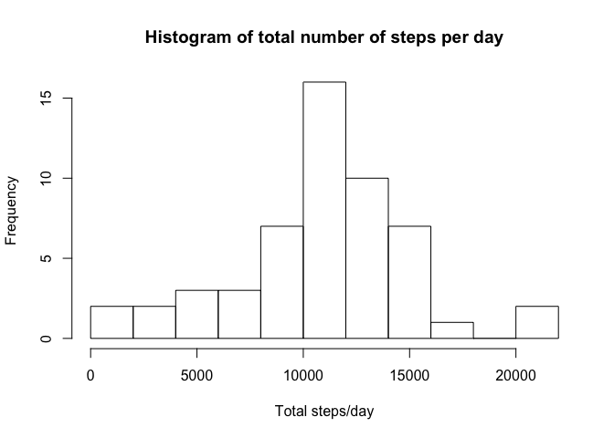

   ```r
   hist(dayactivity$totalsteps, xlab="Total steps/day", main = "Histogram of total number of steps per day", breaks = 10)
   ```

3. Calculate and report the mean and median of the total number of steps taken per day

   ```r
   meantotal<-mean(dayactivity$totalsteps, na.rm = T)
   meantotal
   ```

   ```
   ## [1] 10766.19
   ```

   ```r
   mediantotal<-median(dayactivity$totalsteps, na.rm = T)
   mediantotal
   ```

   ```
   ## [1] 10765
   ```

   The **mean** value of the total number of steps taken per day is **10766.19**.  
   The **median** value of the total number of steps taken per day is **10765**.

## What is the average daily activity pattern?

1. Make a time series plot (i.e. 𝚝𝚢𝚙𝚎 = “𝚕”) of the 5-minute interval (x-axis) and the average number of steps taken, averaged across all days (y-axis)
- Calculate the averaged 5-min interval steps across all the days

  ```r
  activity$interval <- as.factor(activity$interval)
  groupinterval<-group_by(activity,interval)
  meanintsteps<-summarise(groupinterval,meansteps=mean(steps,na.rm=T))
  head(meanintsteps)
  ```

  ```
  ## # A tibble: 6 × 2
  ##   interval meansteps
  ##     <fctr>     <dbl>
  ## 1        0 1.7169811
  ## 2        5 0.3396226
  ## 3       10 0.1320755
  ## 4       15 0.1509434
  ## 5       20 0.0754717
  ## 6       25 2.0943396
  ```

- Make the time series plot

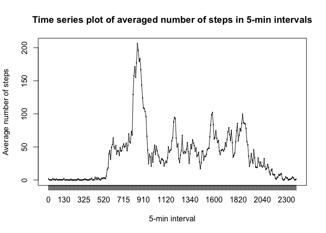

  ```r
  plot(meanintsteps$interval,meanintsteps$meansteps, xlab="5-min interval", ylab="Average number of steps", main="Time series plot of averaged number of steps in 5-min intervals")
  lines(meanintsteps$interval,meanintsteps$meansteps,type="l")
  ```

2. Which 5-minute interval, on average across all the days in the dataset, contains the maximum number of steps?

   ```r
   maxint<-meanintsteps$interval[which.max(meanintsteps$meansteps)]
   maxint
   ```

   ```
   ## [1] 835
   ## 288 Levels: 0 5 10 15 20 25 30 35 40 45 50 55 100 105 110 115 120 ... 2355
   ```

   The **835** interval, which stands for **8:35am to 8:40am**, contains the maximum number of stesp.

## Imputing missing values

1. Calculate and report the total number of missing values in the dataset (i.e. the total number of rows with 𝙽𝙰s)

   ```r
   missings<-sum(is.na(activity$steps))
   missings
   ```

   ```
   ## [1] 2304
   ```

   There are totally **2304** missing values in the dataset.
2. Devise a strategy for filling in all of the missing values in the dataset  
   Use **the mean for that 5-min interval** to fill in missing values.
3. Create a new dataset that is equal to the original dataset but with the missing data filled in

   ```r
   activity1 <- activity %>% mutate(interval=factor(interval))
   for (i in 1:17568)
   {
       if(is.na(activity1$steps[i]))
       {
           activity1$steps[i] <- meanintsteps$meansteps[which(meanintsteps$interval==activity1$interval[i])]
       }
   }
   head(activity1)
   ```

   ```
   ##       steps       date interval
   ## 1 1.7169811 2012-10-01        0
   ## 2 0.3396226 2012-10-01        5
   ## 3 0.1320755 2012-10-01       10
   ## 4 0.1509434 2012-10-01       15
   ## 5 0.0754717 2012-10-01       20
   ## 6 2.0943396 2012-10-01       25
   ```

4. Make a histogram of the total number of steps taken each day.

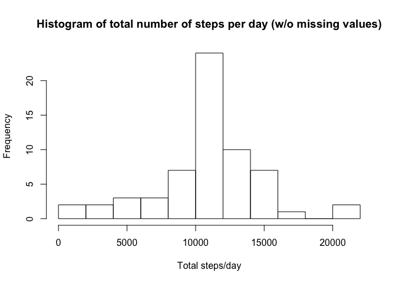

   ```r
   groupdate1<-group_by(activity1,date)
   dayactivity1<-summarise(groupdate1,totalsteps=sum(steps))
   hist(dayactivity1$totalsteps, xlab="Total steps/day", main = "Histogram of total number of steps per day (w/o missing values)", breaks = 10)
   ```

- Calculate and report the mean and median total number of steps taken per day.

  ```r
  meantotal1<-mean(dayactivity1$totalsteps)
  meantotal1
  ```

  ```
  ## [1] 10766.19
  ```

  ```r
  mediantotal1<-median(dayactivity1$totalsteps)
  mediantotal1
  ```

  ```
  ## [1] 10766.19
  ```

## Are there differences in activity patterns between weekdays and weekends?

1. Create a new factor variable in the dataset with two levels – “weekday” and “weekend” indicating whether a given date is a weekday or weekend day.

   ```r
   activity2<-activity1 %>% mutate(weekday=weekdays(as.Date(activity1$date)))
   for (i in 1:17568)
   {
       if(activity2$weekday[i]=="Monday" | activity2$weekday[i]=="Tuesday" |
          activity2$weekday[i]=="Wednesday" | activity2$weekday[i]=="Thursday" |
          activity2$weekday[i]=="Friday")
       {
          activity2$weekday[i]="weekday"
       }
       if(activity2$weekday[i]=="Saturday" | activity2$weekday[i]=="Sunday")
       {
           activity2$weekday[i]="weekend"
       }
   }
   activity2<-mutate(activity2,weekday=factor(weekday))
   head(activity2)
   ```

   ```
   ##       steps       date interval weekday
   ## 1 1.7169811 2012-10-01        0 weekday
   ## 2 0.3396226 2012-10-01        5 weekday
   ## 3 0.1320755 2012-10-01       10 weekday
   ## 4 0.1509434 2012-10-01       15 weekday
   ## 5 0.0754717 2012-10-01       20 weekday
   ## 6 2.0943396 2012-10-01       25 weekday
   ```

2. Make a panel plot containing a time series plot of the 5-minute interval (x-axis) and the average number of steps taken, averaged across all weekday days or weekend days (y-axis).

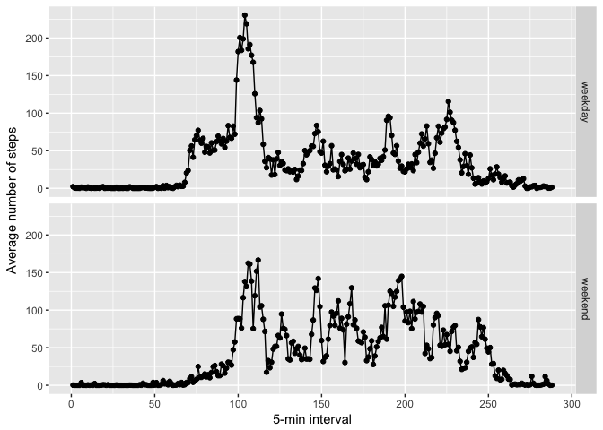

   ```r
   groupIntWeek<-group_by(activity2,interval,weekday)
   meanIntWeek<-summarise(groupIntWeek,meansteps=mean(steps))
   meanIntWeek$interval<-as.numeric(meanIntWeek$interval)
   library(ggplot2, warn.conflicts = FALSE, quietly=TRUE)
   g<-ggplot(meanIntWeek,aes(x=interval,y=meansteps))+
       geom_point()+
       geom_line()+
       facet_grid(weekday~.)+
       xlab("5-min interval")+
       ylab("Average number of steps")+
       scale_x_continuous(breaks = pretty(meanIntWeek$interval, n = 10))
   g
   ```